# Capital Study: Data Cleaning

Group 10

```r
#loading for analysis prepared data table
capital <- read.csv("capital_data.csv")
```

## Data Analysis - Original Study

For the main trials of our experiment we hold the following research hypotheses:

H1: The area under the curve (AUC) is larger for atypical trials compared to typical trials.

H2: The maximal absolute deviation (MAD) is larger for atypical trials compared to typical trials.

H3: Movement duration is longer for atypical trials compared to typical trials.

H4: The likelihood of obtaining different cluster types depends on the experimental conditions.

H5: The total categorisation response time is longer for atypical trials compared to typical trials.

H6: The movement initiation latency is longer for atypical trials compared to typical trials.

H7: The distance travelled in pixels is longer for atypical trials compared to typical trials.

# REGRESSION MODELS

Hypothesis 1

```r
#Taking absolute AUC values, since negative AUC make no sense
capital$AUC_abs = abs(capital$AUC)
capital$AUC_abs_s = my_scale(capital$AUC_abs)

#informative prior
prior_hypo1 <- c(
  #priors for all fixed effects (trial_type)
  set_prior("student_t(3, 0, 2)", class = "sd"),
  #prior for the Intercept
  set_prior("student_t(3, 0, 2)", class = "Intercept"),
  #prior for all SDs including the varying intercepts and slopes
  set_prior("student_t(3, 0, 2)", class = "sigma")
)

#by-subject_id varying intercepts and varying
#slope, without slope/intercept correlation
#by-exemplar varying intercept
model_hypo1 = brm(
  AUC_abs_s ~ trial_type +
    (trial_type || subject_id)+
    (1 |exemplar),
  control=list(adapt_delta=0.99, max_treedepth=15),
  data = capital,
  prior = prior_hypo1
  )

model_hypo1
```

```
##  Family: gaussian
##   Links: mu = identity; sigma = identity
## Formula: AUC_abs_s ~ trial_type + (trial_type || subject_id) + (1 | exemplar)
##    Data: capital (Number of observations: 463)
## Samples: 4 chains, each with iter = 2000; warmup = 1000; thin = 1;
##          total post-warmup samples = 4000
##
## Group-Level Effects:
## ~exemplar (Number of levels: 14)
##               Estimate Est.Error l-95% CI u-95% CI Rhat Bulk_ESS Tail_ESS
## sd(Intercept)     0.13      0.08     0.01     0.31 1.00     1034     1588
##
## ~subject_id (Number of levels: 53)
##                       Estimate Est.Error l-95% CI u-95% CI Rhat Bulk_ESS
## sd(Intercept)             0.49      0.07     0.37     0.65 1.01     1440
## sd(trial_typeTypical)     0.13      0.09     0.01     0.34 1.00      904
##                       Tail_ESS
## sd(Intercept)             2433
## sd(trial_typeTypical)     1732
##
## Population-Level Effects:
##                   Estimate Est.Error l-95% CI u-95% CI Rhat Bulk_ESS Tail_ESS
## Intercept             0.02      0.11    -0.19     0.25 1.00     2255     2398
## trial_typeTypical    -0.01      0.12    -0.25     0.24 1.00     2900     2427
##
## Family Specific Parameters:
##       Estimate Est.Error l-95% CI u-95% CI Rhat Bulk_ESS Tail_ESS
## sigma     0.87      0.03     0.81     0.94 1.00     4505     2668
##
## Samples were drawn using sampling(NUTS). For each parameter, Bulk_ESS
## and Tail_ESS are effective sample size measures, and Rhat is the potential
## scale reduction factor on split chains (at convergence, Rhat = 1).
```

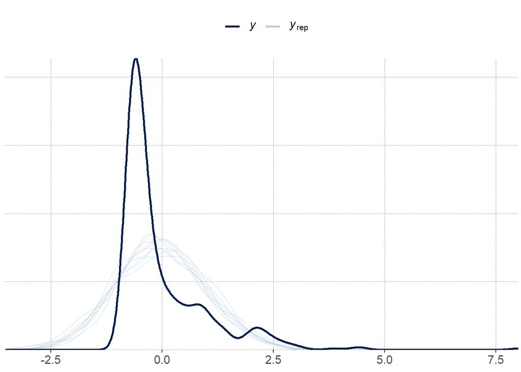

```r
#fitting the model to the actual data
pp_check(model_hypo1)
```

```r
# Extract the posteriors
posteriors1_trial_type <- model_hypo1 %>%
  spread_draws(b_Intercept,
               b_trial_typeTypical) %>%
  # calculate posteriors for each individual level
  mutate(Atypical = b_Intercept,
         Typical = b_Intercept + b_trial_typeTypical) %>%
  select(Atypical, Typical) %>%
  gather(key = "parameter", value = "posterior") %>%
  group_by(parameter) %>%
  summarise(mean_posterior = mean(posterior),
            `95lowerCrI` = HDInterval::hdi(posterior, credMass = 0.90)[1],
            `95higherCrI` = HDInterval::hdi(posterior, credMass = 0.90)[2])

posteriors1_trial_type
```

```
## # A tibble: 2 x 4
##   parameter mean_posterior `95lowerCrI` `95higherCrI`
##   <chr>              <dbl>        <dbl>         <dbl>
## 1 Atypical          0.0231       -0.155         0.212
## 2 Typical           0.0166       -0.148         0.195
```

```r
# Extract the posteriors
posteriors1 <- model_hypo1 %>%
  spread_draws(b_trial_typeTypical) %>%
  select(b_trial_typeTypical) %>%
  gather(key = "parameter", value = "posterior")


posteriors1
```

```
## # A tibble: 4,000 x 2
##    parameter           posterior
##    <chr>                   <dbl>
##  1 b_trial_typeTypical   -0.0230
##  2 b_trial_typeTypical    0.136
##  3 b_trial_typeTypical    0.0214
##  4 b_trial_typeTypical    0.0316
##  5 b_trial_typeTypical    0.0237
##  6 b_trial_typeTypical   -0.143
##  7 b_trial_typeTypical    0.115
##  8 b_trial_typeTypical    0.197
##  9 b_trial_typeTypical    0.0296
## 10 b_trial_typeTypical    0.0528
## # ... with 3,990 more rows
```

```r
posterior1_agg <- posteriors1 %>%
  mutate(mean_posterior = mean(posterior))

posterior1_agg
```

```
## # A tibble: 4,000 x 3
##    parameter           posterior mean_posterior
##    <chr>                   <dbl>          <dbl>
##  1 b_trial_typeTypical   -0.0230       -0.00654
##  2 b_trial_typeTypical    0.136        -0.00654
##  3 b_trial_typeTypical    0.0214       -0.00654
##  4 b_trial_typeTypical    0.0316       -0.00654
##  5 b_trial_typeTypical    0.0237       -0.00654
##  6 b_trial_typeTypical   -0.143        -0.00654
##  7 b_trial_typeTypical    0.115        -0.00654
##  8 b_trial_typeTypical    0.197        -0.00654
##  9 b_trial_typeTypical    0.0296       -0.00654
## 10 b_trial_typeTypical    0.0528       -0.00654
## # ... with 3,990 more rows
```

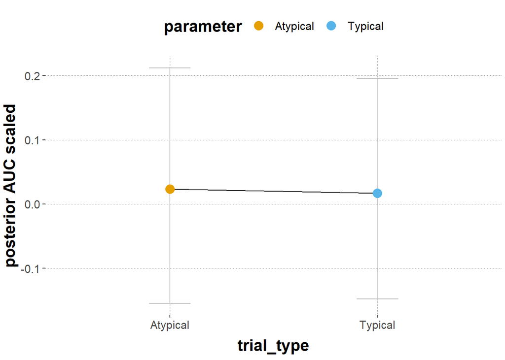

```r
# plot
ggplot(data = posteriors1_trial_type,
       aes(x = parameter, y = mean_posterior,
           color = parameter, fill = parameter)) +
  geom_errorbar(aes(ymin = `95lowerCrI`, ymax = `95higherCrI`),
                width = 0.2, color = "grey") +
  geom_line(aes(group = 1), color = "black") +
  geom_point(size = 4) +
  labs(x = "trial_type",
       y = "posterior AUC scaled")
```

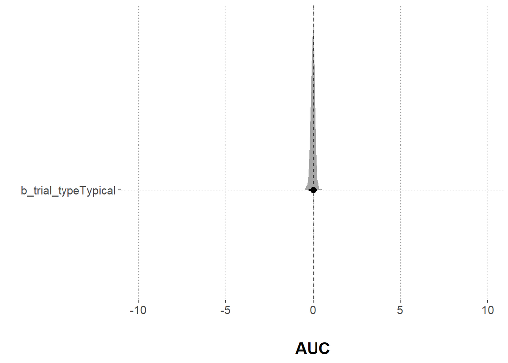

```r
# plot the regression coefficients
  ggplot(posteriors1, aes(x = posterior, y = parameter)) +
    # plot density
    geom_halfeyeh(.width = 0.95) +
    # add axes titles
    xlab("\nAUC") +
    ylab("") +
    # adjust the x-axis
    scale_x_continuous(limits = c(-10,10)) +
    # add line for the value zero
    geom_segment(x = 0, xend = 0, y = Inf, yend = -Inf,
                 lty = "dashed")
```

Results: The mean posterior scaled AUC values are for both trial types almost the same. The credible interval of the coefficient trial_typeTypical includes 0, wherefore there is no compelling evidence for the hypothesis to hold true.

Hypothesis 2

```r
#Taking absolute AUC values, since negative AUC make no sense
capital$MAD_abs = abs(capital$MAD)
capital$MAD_abs_s = my_scale(capital$MAD_abs)

#informative prior
prior_hypo2 <- c(
  #priors for all fixed effects (trial_type)
  set_prior("student_t(3, 0, 2)", class = "sigma"),
  #prior for the Intercept
  set_prior("student_t(3, 0, 2)", class = "Intercept"),
  #prior for all SDs including the varying intercepts and slopes
  set_prior("student_t(3, 0, 2)", class = "sd")
)

#by-subject_id varying intercepts and varying
#slope, without slope/intercept correlation
#by-exemplar varying intercept
model_hypo2 = brm(
  MAD_abs_s ~ trial_type +
    (trial_type || subject_id)+
    (1|exemplar),
  control=list(adapt_delta=0.99, max_treedepth=15),
  data = capital,
  prior = prior_hypo2
  )

model_hypo2
```

```
##  Family: gaussian
##   Links: mu = identity; sigma = identity
## Formula: MAD_abs_s ~ trial_type + (trial_type || subject_id) + (1 | exemplar)
##    Data: capital (Number of observations: 463)
## Samples: 4 chains, each with iter = 2000; warmup = 1000; thin = 1;
##          total post-warmup samples = 4000
##
## Group-Level Effects:
## ~exemplar (Number of levels: 14)
##               Estimate Est.Error l-95% CI u-95% CI Rhat Bulk_ESS Tail_ESS
## sd(Intercept)     0.12      0.08     0.01     0.30 1.01      946     1507
##
## ~subject_id (Number of levels: 53)
##                       Estimate Est.Error l-95% CI u-95% CI Rhat Bulk_ESS
## sd(Intercept)             0.44      0.07     0.32     0.59 1.00     1364
## sd(trial_typeTypical)     0.12      0.09     0.00     0.33 1.01     1021
##                       Tail_ESS
## sd(Intercept)             1865
## sd(trial_typeTypical)     1816
##
## Population-Level Effects:
##                   Estimate Est.Error l-95% CI u-95% CI Rhat Bulk_ESS Tail_ESS
## Intercept             0.06      0.11    -0.15     0.27 1.00     2677     2931
## trial_typeTypical    -0.05      0.12    -0.29     0.19 1.00     3558     2268
##
## Family Specific Parameters:
##       Estimate Est.Error l-95% CI u-95% CI Rhat Bulk_ESS Tail_ESS
## sigma     0.90      0.03     0.84     0.97 1.00     4100     2852
##
## Samples were drawn using sampling(NUTS). For each parameter, Bulk_ESS
## and Tail_ESS are effective sample size measures, and Rhat is the potential
## scale reduction factor on split chains (at convergence, Rhat = 1).
```

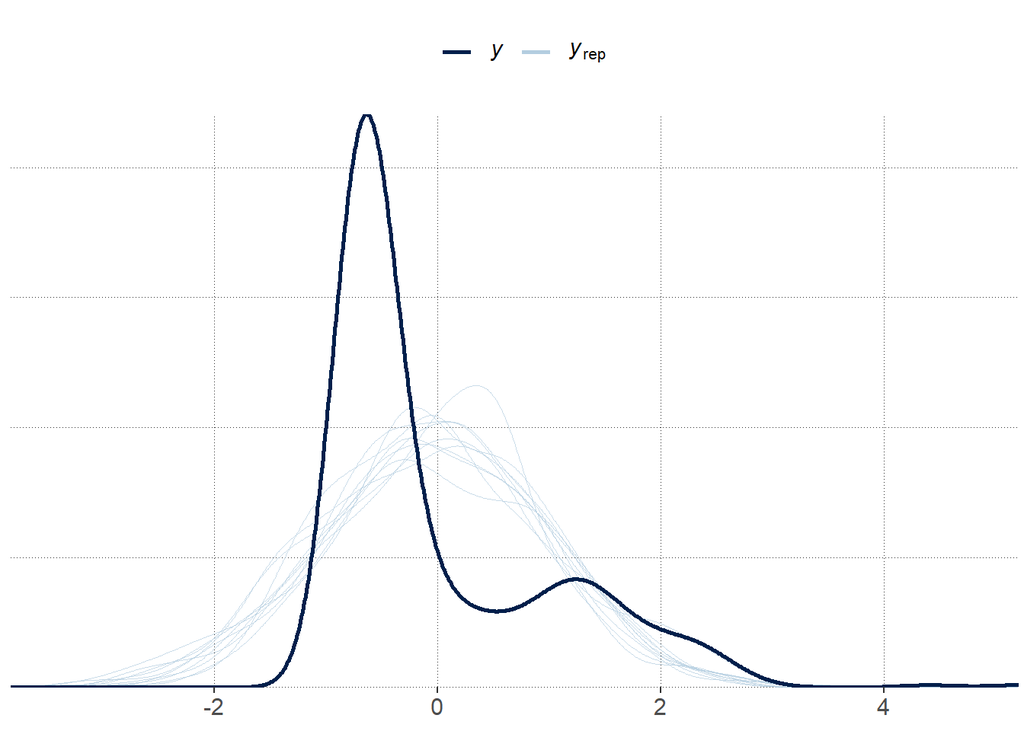

```r
#fitting the model to the actual data
pp_check(model_hypo2)
```

```r
# Extract the posteriors
posteriors2_trial_type <- model_hypo2 %>%
  spread_draws(b_Intercept,
               b_trial_typeTypical) %>%
  # calculate posteriors for each individual level
  mutate(Atypical = b_Intercept,
         Typical = b_Intercept + b_trial_typeTypical) %>%
  select(Atypical, Typical) %>%
  gather(key = "parameter", value = "posterior") %>%
  group_by(parameter) %>%
  summarise(mean_posterior = mean(posterior),
            `95lowerCrI` = HDInterval::hdi(posterior, credMass = 0.90)[1],
            `95higherCrI` = HDInterval::hdi(posterior, credMass = 0.90)[2])

posteriors2_trial_type
```

```
## # A tibble: 2 x 4
##   parameter mean_posterior `95lowerCrI` `95higherCrI`
##   <chr>              <dbl>        <dbl>         <dbl>
## 1 Atypical         0.0555        -0.130         0.223
## 2 Typical          0.00694       -0.164         0.158
```

```r
# Extract the posteriors
posteriors2 <- model_hypo2 %>%
  spread_draws(b_trial_typeTypical) %>%
  select(b_trial_typeTypical) %>%
  gather(key = "parameter", value = "posterior")


posteriors2
```

```
## # A tibble: 4,000 x 2
##    parameter           posterior
##    <chr>                   <dbl>
##  1 b_trial_typeTypical  -0.238
##  2 b_trial_typeTypical  -0.300
##  3 b_trial_typeTypical  -0.0591
##  4 b_trial_typeTypical   0.00648
##  5 b_trial_typeTypical  -0.0654
##  6 b_trial_typeTypical  -0.0591
##  7 b_trial_typeTypical  -0.126
##  8 b_trial_typeTypical  -0.0817
##  9 b_trial_typeTypical   0.00623
## 10 b_trial_typeTypical   0.0147
## # ... with 3,990 more rows
```

```r
posterior2_agg <- posteriors2 %>%
  mutate(mean_posterior = mean(posterior))

posterior2_agg
```

```
## # A tibble: 4,000 x 3
##    parameter           posterior mean_posterior
##    <chr>                   <dbl>          <dbl>
##  1 b_trial_typeTypical  -0.238          -0.0486
##  2 b_trial_typeTypical  -0.300          -0.0486
##  3 b_trial_typeTypical  -0.0591         -0.0486
##  4 b_trial_typeTypical   0.00648        -0.0486
##  5 b_trial_typeTypical  -0.0654         -0.0486
##  6 b_trial_typeTypical  -0.0591         -0.0486
##  7 b_trial_typeTypical  -0.126          -0.0486
##  8 b_trial_typeTypical  -0.0817         -0.0486
##  9 b_trial_typeTypical   0.00623        -0.0486
## 10 b_trial_typeTypical   0.0147         -0.0486
## # ... with 3,990 more rows
```

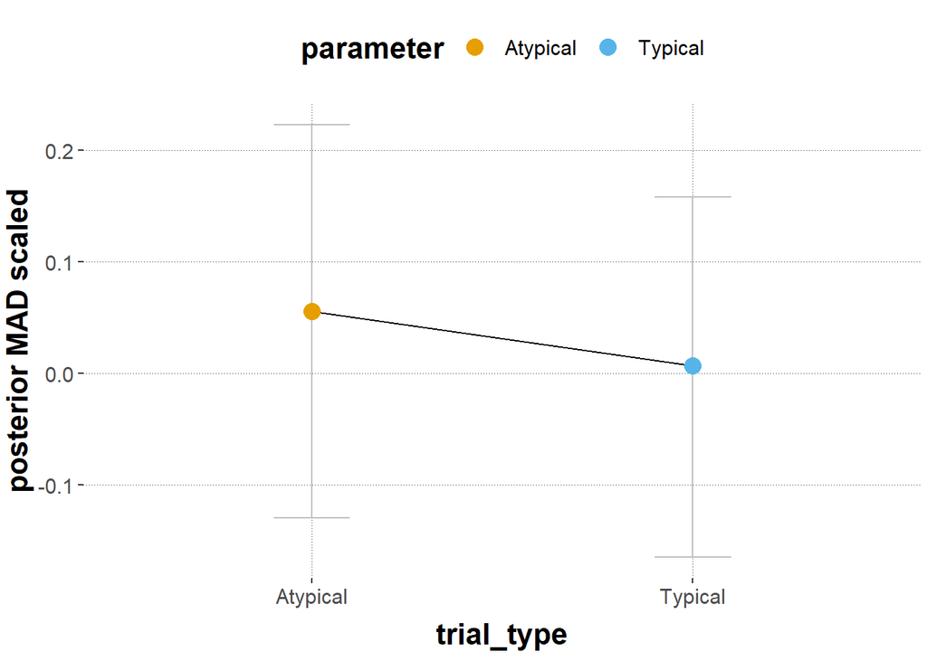

```r
# plot
ggplot(data = posteriors2_trial_type,
       aes(x = parameter, y = mean_posterior,
           color = parameter, fill = parameter)) +
  geom_errorbar(aes(ymin = `95lowerCrI`, ymax = `95higherCrI`),
                width = 0.2, color = "grey") +
  geom_line(aes(group = 1), color = "black") +
  geom_point(size = 4) +
  labs(x = "trial_type",
       y = "posterior MAD scaled")
```

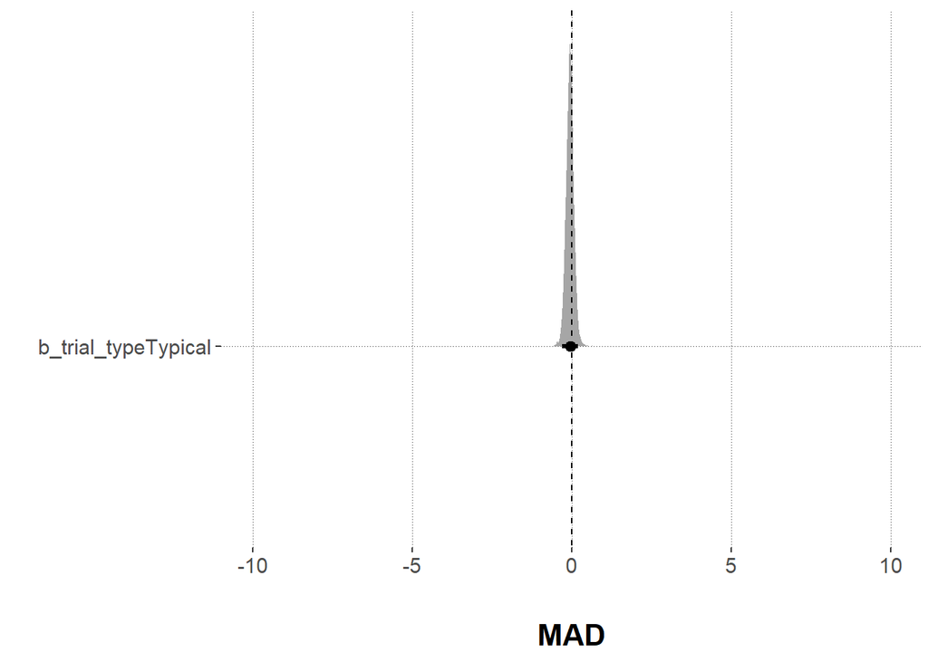

```r
# plot the regression coefficients
  ggplot(posteriors2, aes(x = posterior, y = parameter)) +
    # plot density
    geom_halfeyeh(.width = 0.95) +
    # add axes titles
    xlab("\nMAD") +
    ylab("") +
    # adjust the x-axis
    scale_x_continuous(limits = c(-10,10)) +
    # add line for the value zero
    geom_segment(x = 0, xend = 0, y = Inf, yend = -Inf,
                 lty = "dashed")
```

Results: Absolute scaled mean posterior MAD values are higher for Atypical than Typical trial types, due to the negative slope going from the reference level (Atypical) to the Typical trial type. The credible interval of the coefficient trial_typeTypical includes 0, wherefore there is no compelling evidence for the hypothesis to hold true.

Hypothesis 3

```r
capital$mousetrackingDuration_s = my_scale(capital$mousetrackingDuration)

#informative prior
prior_hypo3 <- c(
  #priors for all fixed effects (trial_type)
  set_prior("student_t(3, 0, 2)", class = "sigma"),
  #prior for the Intercept
  set_prior("student_t(3, 0, 2)", class = "Intercept"),
  #prior for all SDs including the varying intercepts and slopes
  set_prior("student_t(3, 0, 2)", class = "sd")
)

#by-subject_id varying intercepts and varying
#slope, without slope/intercept correlation
#by-exemplar varying intercept
model_hypo3 = brm(
  mousetrackingDuration_s ~ trial_type +
    (trial_type || subject_id)+
    (1|exemplar),
  control=list(adapt_delta=0.99, max_treedepth=15),
  data = capital,
  prior = prior_hypo3
  )

model_hypo3
```

```
##  Family: gaussian
##   Links: mu = identity; sigma = identity
## Formula: mousetrackingDuration_s ~ trial_type + (trial_type || subject_id) + (1 | exemplar)
##    Data: capital (Number of observations: 463)
## Samples: 4 chains, each with iter = 2000; warmup = 1000; thin = 1;
##          total post-warmup samples = 4000
##
## Group-Level Effects:
## ~exemplar (Number of levels: 14)
##               Estimate Est.Error l-95% CI u-95% CI Rhat Bulk_ESS Tail_ESS
## sd(Intercept)     0.31      0.09     0.17     0.52 1.00     1354     1664
##
## ~subject_id (Number of levels: 53)
##                       Estimate Est.Error l-95% CI u-95% CI Rhat Bulk_ESS
## sd(Intercept)             0.60      0.08     0.46     0.77 1.00      817
## sd(trial_typeTypical)     0.18      0.11     0.01     0.41 1.01      393
##                       Tail_ESS
## sd(Intercept)             1699
## sd(trial_typeTypical)     1191
##
## Population-Level Effects:
##                   Estimate Est.Error l-95% CI u-95% CI Rhat Bulk_ESS Tail_ESS
## Intercept             0.42      0.16     0.10     0.73 1.00     1434     2151
## trial_typeTypical    -0.67      0.19    -1.05    -0.29 1.00     1473     1972
##
## Family Specific Parameters:
##       Estimate Est.Error l-95% CI u-95% CI Rhat Bulk_ESS Tail_ESS
## sigma     0.71      0.03     0.66     0.77 1.00     1834     2903
##
## Samples were drawn using sampling(NUTS). For each parameter, Bulk_ESS
## and Tail_ESS are effective sample size measures, and Rhat is the potential
## scale reduction factor on split chains (at convergence, Rhat = 1).
```

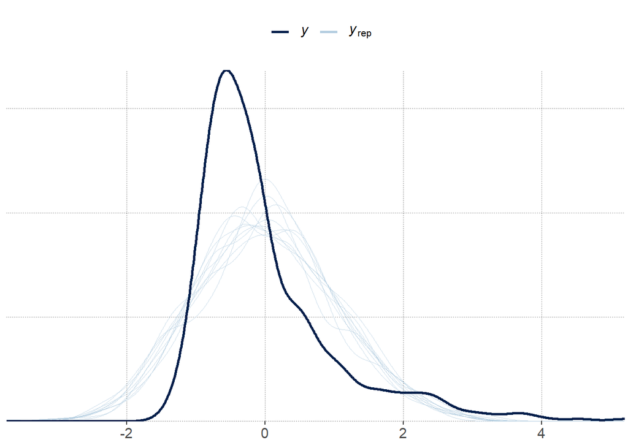

```r
#fitting the model to the actual data
pp_check(model_hypo3)
```

```r
# Extract the posteriors
posteriors3_trial_type <- model_hypo3 %>%
  spread_draws(b_Intercept,
               b_trial_typeTypical) %>%
  # calculate posteriors for each individual level
  mutate(Atypical = b_Intercept,
         Typical = b_Intercept + b_trial_typeTypical) %>%
  select(Atypical, Typical) %>%
  gather(key = "parameter", value = "posterior") %>%
  group_by(parameter) %>%
  summarise(mean_posterior = mean(posterior),
            `95lowerCrI` = HDInterval::hdi(posterior, credMass = 0.90)[1],
            `95higherCrI` = HDInterval::hdi(posterior, credMass = 0.90)[2])

posteriors3_trial_type
```

```
## # A tibble: 2 x 4
##   parameter mean_posterior `95lowerCrI` `95higherCrI`
##   <chr>              <dbl>        <dbl>         <dbl>
## 1 Atypical           0.417        0.150        0.661
## 2 Typical           -0.254       -0.516       -0.0105
```

```r
# Extract the posteriors
posteriors3 <- model_hypo3 %>%
  spread_draws(b_trial_typeTypical) %>%
  select(b_trial_typeTypical) %>%
  gather(key = "parameter", value = "posterior")


posteriors3
```

```
## # A tibble: 4,000 x 2
##    parameter           posterior
##    <chr>                   <dbl>
##  1 b_trial_typeTypical    -1.06
##  2 b_trial_typeTypical    -1.11
##  3 b_trial_typeTypical    -0.668
##  4 b_trial_typeTypical    -0.681
##  5 b_trial_typeTypical    -0.409
##  6 b_trial_typeTypical    -0.422
##  7 b_trial_typeTypical    -0.400
##  8 b_trial_typeTypical    -0.422
##  9 b_trial_typeTypical    -0.268
## 10 b_trial_typeTypical    -0.204
## # ... with 3,990 more rows
```

```r
posterior3_agg <- posteriors3 %>%
  mutate(mean_posterior = mean(posterior))

posterior3_agg
```

```
## # A tibble: 4,000 x 3
##    parameter           posterior mean_posterior
##    <chr>                   <dbl>          <dbl>
##  1 b_trial_typeTypical    -1.06          -0.671
##  2 b_trial_typeTypical    -1.11          -0.671
##  3 b_trial_typeTypical    -0.668         -0.671
##  4 b_trial_typeTypical    -0.681         -0.671
##  5 b_trial_typeTypical    -0.409         -0.671
##  6 b_trial_typeTypical    -0.422         -0.671
##  7 b_trial_typeTypical    -0.400         -0.671
##  8 b_trial_typeTypical    -0.422         -0.671
##  9 b_trial_typeTypical    -0.268         -0.671
## 10 b_trial_typeTypical    -0.204         -0.671
## # ... with 3,990 more rows
```

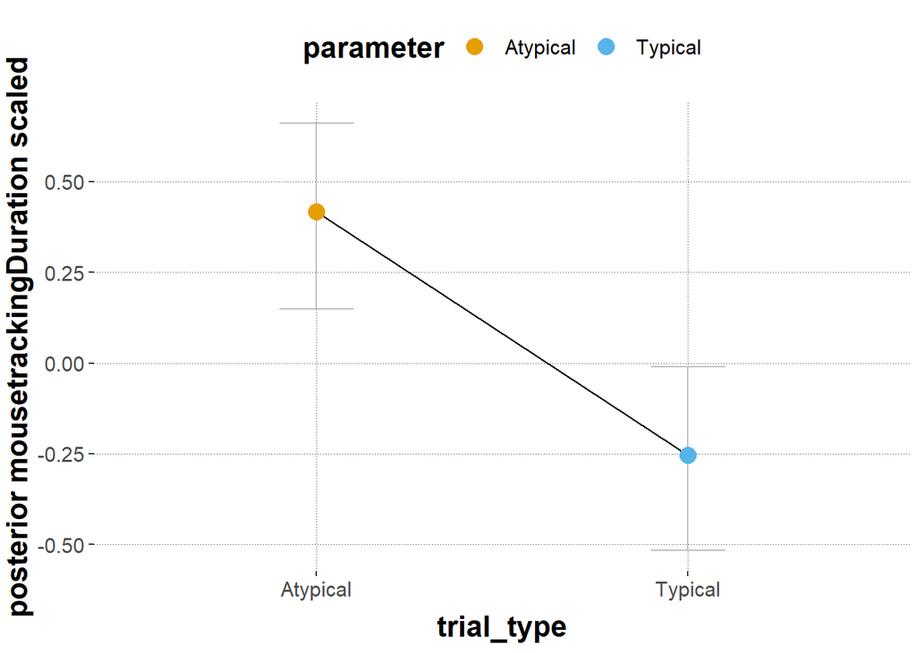

```r
# plot
ggplot(data = posteriors3_trial_type,
       aes(x = parameter, y = mean_posterior,
           color = parameter, fill = parameter)) +
  geom_errorbar(aes(ymin = `95lowerCrI`, ymax = `95higherCrI`),
                width = 0.2, color = "grey") +
  geom_line(aes(group = 1), color = "black") +
  geom_point(size = 4) +
  labs(x = "trial_type",
       y = "posterior mousetrackingDuration scaled")
```

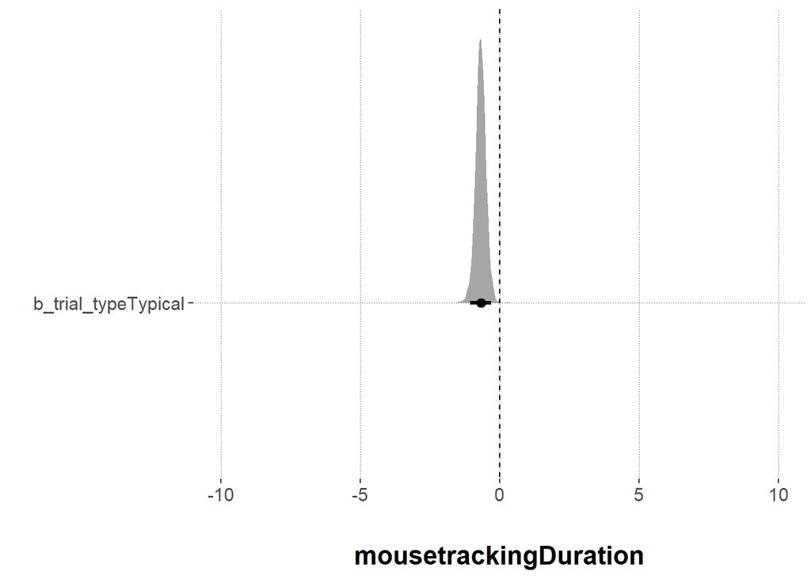

```r
# plot the regression coefficients
  ggplot(posteriors3, aes(x = posterior, y = parameter)) +
    # plot density
    geom_halfeyeh(.width = 0.95) +
    # add axes titles
    xlab("\nmousetrackingDuration") +
    ylab("") +
    # adjust the x-axis
    scale_x_continuous(limits = c(-10,10)) +
    # add line for the value zero
    geom_segment(x = 0, xend = 0, y = Inf, yend = -Inf,
                 lty = "dashed")
```

```r
#computing evidential ratio and posterior probability
hypothesis(model_hypo3, "trial_typeTypical > -0.67")
```

```
## Hypothesis Tests for class b:
##                 Hypothesis Estimate Est.Error CI.Lower CI.Upper Evid.Ratio
## 1 (trial_typeTypica... > 0        0      0.19     -0.3      0.3       0.99
##   Post.Prob Star
## 1       0.5
## ---
## 'CI': 90%-CI for one-sided and 95%-CI for two-sided hypotheses.
## '*': For one-sided hypotheses, the posterior probability exceeds 95%;
## for two-sided hypotheses, the value tested against lies outside the 95%-CI.
## Posterior probabilities of point hypotheses assume equal prior probabilities.
```

Hypothesis 4

```r
capital$factor_prototype_label <- factor(capital$prototype_label)

#multinomial logistic regression model
#by-subject_id varying intercepts and varying
#slope, without slope/intercept correlation
#by-exemplar varying intercept
model_hypo4 <- brm(
  factor_prototype_label ~ trial_type +
    (trial_type || subject_id)+
    (1|exemplar),
  data = capital,
  family = categorical(link = "logit", refcat = NULL)
)

model_hypo4
```

```
##  Family: categorical
##   Links: mucurved = logit; mudCoM = logit; mudCoM2 = logit; mustraight = logit
## Formula: factor_prototype_label ~ trial_type + (trial_type || subject_id) + (1 | exemplar)
##    Data: capital (Number of observations: 463)
## Samples: 4 chains, each with iter = 2000; warmup = 1000; thin = 1;
##          total post-warmup samples = 4000
##
## Group-Level Effects:
## ~exemplar (Number of levels: 14)
##                          Estimate Est.Error l-95% CI u-95% CI Rhat Bulk_ESS
## sd(mucurved_Intercept)       0.25      0.21     0.01     0.76 1.00     2020
## sd(mudCoM_Intercept)         0.66      0.42     0.04     1.64 1.00      986
## sd(mudCoM2_Intercept)        1.33      0.96     0.07     3.66 1.00     1038
## sd(mustraight_Intercept)     0.23      0.18     0.01     0.64 1.00     1353
##                          Tail_ESS
## sd(mucurved_Intercept)       2240
## sd(mudCoM_Intercept)         1527
## sd(mudCoM2_Intercept)        1666
## sd(mustraight_Intercept)     1740
##
## ~subject_id (Number of levels: 53)
##                                  Estimate Est.Error l-95% CI u-95% CI Rhat
## sd(mucurved_Intercept)               2.89      0.56     1.96     4.18 1.00
## sd(mucurved_trial_typeTypical)       0.63      0.48     0.04     1.77 1.00
## sd(mudCoM_Intercept)                 1.24      0.40     0.51     2.12 1.00
## sd(mudCoM_trial_typeTypical)         0.73      0.51     0.04     1.87 1.00
## sd(mudCoM2_Intercept)                0.77      0.60     0.03     2.19 1.00
## sd(mudCoM2_trial_typeTypical)        1.68      1.29     0.08     4.88 1.00
## sd(mustraight_Intercept)             0.92      0.25     0.45     1.42 1.00
## sd(mustraight_trial_typeTypical)     0.39      0.28     0.02     1.02 1.00
##                                  Bulk_ESS Tail_ESS
## sd(mucurved_Intercept)               1761     2281
## sd(mucurved_trial_typeTypical)       1082     1709
## sd(mudCoM_Intercept)                 1133     1437
## sd(mudCoM_trial_typeTypical)         1017     2098
## sd(mudCoM2_Intercept)                1593     2049
## sd(mudCoM2_trial_typeTypical)         679      731
## sd(mustraight_Intercept)             1068     1328
## sd(mustraight_trial_typeTypical)      976     1783
##
```

[output cut: 8 more lines]

```
## mudCoM2_trial_typeTypical       -1.49      1.95    -6.26     1.61 1.00     1082
## mustraight_trial_typeTypical     0.28      0.34    -0.37     0.96 1.00     4943
##                              Tail_ESS
## mucurved_Intercept               2222
## mudCoM_Intercept                 2896
## mudCoM2_Intercept                2513
## mustraight_Intercept             3034
## mucurved_trial_typeTypical       2828
## mudCoM_trial_typeTypical         2385
## mudCoM2_trial_typeTypical         736
## mustraight_trial_typeTypical     3101
##
## Samples were drawn using sampling(NUTS). For each parameter, Bulk_ESS
## and Tail_ESS are effective sample size measures, and Rhat is the potential
## scale reduction factor on split chains (at convergence, Rhat = 1).
```

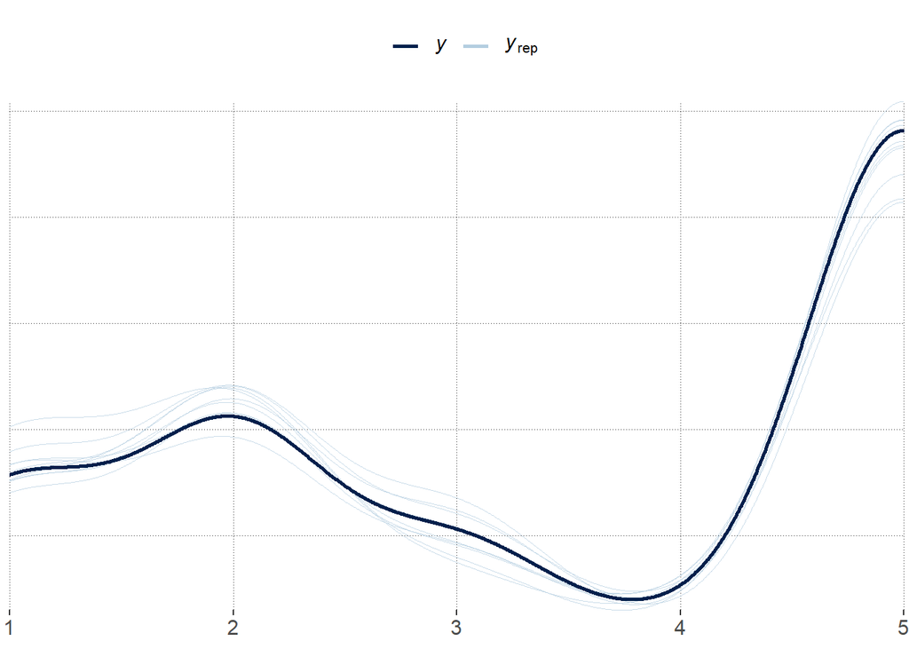

```r
#fitting model to the actual data
pp_check(model_hypo4)
```

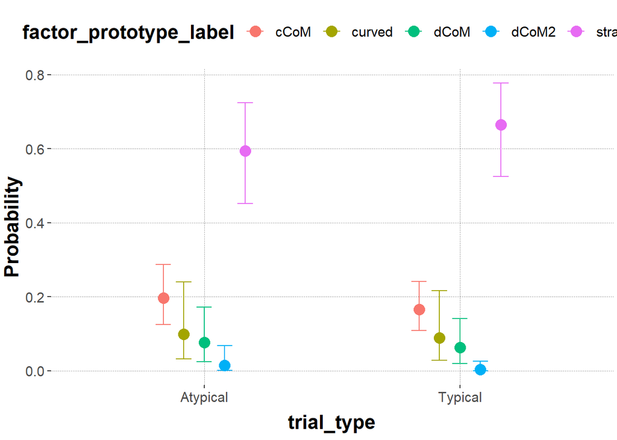

```r
#plotting marginal probabilities
marginal_effects(model_hypo4, "trial_type", categorical = TRUE)
```

```r
#extracting posteriors
predicted_hypo4 <- model_hypo4 %>%
  spread_draws(b_mucurved_Intercept,
               b_mudCoM_Intercept,
               b_mustraight_Intercept,
               b_mudCoM2_Intercept,
               b_mucurved_trial_typeTypical,
               b_mudCoM_trial_typeTypical,
               b_mustraight_trial_typeTypical,
               b_mudCoM2_trial_typeTypical) %>%
  # mutating the parameters with their coefficient combination
  mutate(curved_Atypical = plogis(b_mucurved_Intercept),
         curved_Typical = plogis(b_mucurved_Intercept + b_mucurved_trial_typeTypical),
         dCoM_Atypical = plogis(b_mudCoM_Intercept),
          dCoM_Typical = plogis(b_mudCoM_Intercept + b_mudCoM_trial_typeTypical),
         straight_Atypical = plogis(b_mustraight_Intercept),
         straight_Typical = plogis(b_mustraight_Intercept + b_mustraight_trial_typeTypical),
         dCoM2_Atypical = plogis(b_mudCoM2_Intercept),
          dCoM2_Typical = plogis(b_mudCoM2_Intercept + b_mudCoM2_trial_typeTypical),
         cCoM_Atypical = plogis(b_mucurved_Intercept + b_mudCoM_Intercept + b_mustraight_Intercept + b_mudCoM2_Intercept),
         cCoM_Typical = plogis(b_mucurved_Intercept + b_mudCoM_Intercept + b_mustraight_Intercept + b_mucurved_trial_typeTypical +
                             b_mudCoM_trial_typeTypical + b_mustraight_trial_typeTypical + b_mudCoM2_Intercept + b_mudCoM2_trial_typeTypical)) %>%
  select(curved_Atypical, curved_Typical, dCoM_Atypical, dCoM_Typical, dCoM2_Atypical, dCoM2_Typical, straight_Atypical, straight_Typical, cCoM_Atypical, cCoM_Typical) %>%
  gather(key = "parameter", value = "posterior") %>%
  #muatating categories for cluster and condition for better plotting
   mutate(prototype = ifelse(parameter == "curved_Atypical" | parameter == "curved_Typical",
                        "curved",ifelse(parameter == "dCoM_Atypical"|parameter == "dCoM_Typical", "dCoM", ifelse(parameter == "straight_Atypical"|parameter == "straight_Typical", "straight", ifelse(parameter == "dCoM2_Atypical" | parameter == "dCoM2_Typical",
                        "dCoM2", "cCoM")))),
          trial_type = ifelse(parameter == "curved_Atypical" | parameter == "dCoM_Atypical" | parameter == "straight_Atypical" | parameter == "cCoM_Atypical"| parameter == "dCoM2_Atypical",
                        "Atypical", "Typical")) %>%
  group_by(prototype, trial_type) %>%
  summarise(mean_posterior = mean(posterior),
            `95lowerCrI` = HDInterval::hdi(posterior, credMass = 0.90)[1],
            `95higherCrI` = HDInterval::hdi(posterior, credMass = 0.90)[2])

predicted_hypo4
```

```
## # A tibble: 10 x 5
## # Groups:   prototype [5]
##    prototype trial_type mean_posterior `95lowerCrI` `95higherCrI`
##    <chr>     <chr>               <dbl>        <dbl>         <dbl>
##  1 cCoM      Atypical           0.0740  0.0000537          0.190
##  2 cCoM      Typical            0.0354  0.000000118        0.0940
##  3 curved    Atypical           0.340   0.148              0.539
##  4 curved    Typical            0.353   0.159              0.549
##  5 dCoM      Atypical           0.284   0.115              0.444
##  6 dCoM      Typical            0.278   0.123              0.435
##  7 dCoM2     Atypical           0.0866  0.000208           0.173
##  8 dCoM2     Typical            0.0333  0.000000400        0.0803
##  9 straight  Atypical           0.747   0.662              0.833
## 10 straight  Typical            0.796   0.729              0.865
```

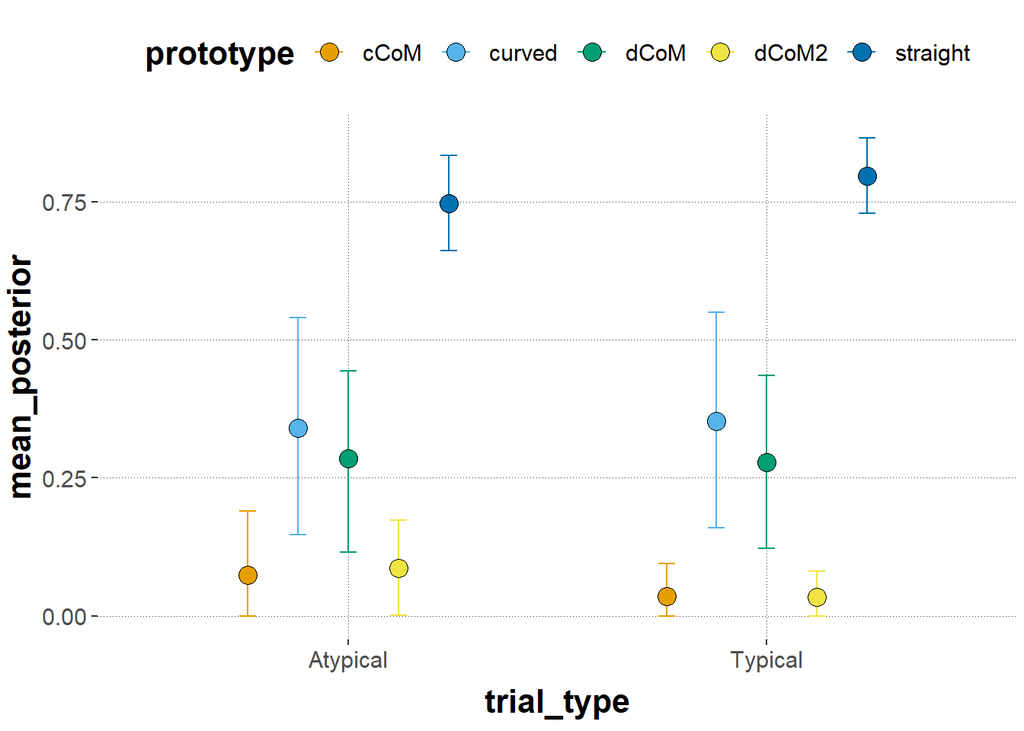

```r
#plotting mean posterior probability of every prototype for each trial type
ggplot(predicted_hypo4) +
   geom_errorbar(aes(x = trial_type, y = mean_posterior, color = prototype,
                    ymin = `95lowerCrI`, ymax = `95higherCrI`),
                width = 0.2,  position = position_dodge(width = 0.6)) +
  geom_point(aes(x = trial_type, y = mean_posterior, fill = prototype),
             size = 4, pch = 21, color = "black", position = position_dodge(0.6))
```

Results: The graph indicates the mean posterior probabilities of the prototypes for each trial type.Taking from the graph there are no big differences between the prototype occuerences of trial types. For the prototype straight the mean posteriors are the highest in both trial types. Overall no noteworthy influence of the experimental condition can be seen on the likelihood of obtaining different amounts of prototypes.